# Solution_lab10

As usual, let's begin importing some useful libraries. Note the presence of several visualization customizations. `plt.style.use()` lets us specify a style family among some predefined samples (see other options on the [matlplotlib style reference page](https://matplotlib.org/3.1.1/gallery/style_sheets/style_sheets_reference.html). Then, the `rcParams` dictionary can be used to change the default style settings and behaviors of matplolib. In this case, we are increasing the default figure size to 12x6 inches. Finally, setting the `max_rows` attribute for pandas forces the number of rows to be displayed whenever a DataFrame is printed.

```python
import numpy as np
import pandas as pd
import matplotlib.pyplot as plt
%matplotlib inline

plt.style.use('seaborn-notebook')
pd.options.display.max_rows = 10
```

```python
plt.rcParams["figure.figsize"] = (12, 6)
```

## Exercise 1: Data exploration of Point of Interest

### Exercise 1.1

Let's load the two files using pandas. The first file contains several information related to Points of Interest (POI) in the New York area. The second one contains the IDs of those POIs located in the New York municipality. To retain only the latter points, we can use the DataFrame index functionalities. The operation is equivalent to the set operator of intersection between the two indices.

```python
ny_pois_ids = np.loadtxt("ny_municipality_pois_id.csv")

# This dictionary maps attributes in the table with correct data types
d_types = {'@type':str, '@lat':float, '@lon':float, 'amenity':str, 'name':str,
           'shop':str, 'public_transport':str, 'highway':str}
all_pois_df = pd.read_csv("pois_all_info", sep='\t', index_col='@id', dtype=d_types)

# Filter only POIS in NY municipality: intersection on indices
pois_df = all_pois_df.loc[ny_pois_ids]
pois_df
```

| @id | @type | @lat | @lon | amenity | name | shop | public_transport | highway |
| --- | --- | --- | --- | --- | --- | --- | --- | --- |
| 42432939 | node | 40.814104 | -73.949623 | NaN | NaN | NaN | stop_position | NaN |
| 42448838 | node | 40.761647 | -73.949864 | NaN | NaN | NaN | stop_position | NaN |
| 42723103 | node | 40.852182 | -73.772677 | ferry_terminal | Hart Island Ferry Terminal | NaN | NaN | NaN |
| 42764076 | node | 40.867164 | -73.882158 | NaN | Botanical Garden | NaN | stop_position | NaN |
| 42811266 | node | 40.704807 | -73.772734 | NaN | NaN | NaN | stop_position | NaN |
| ... | ... | ... | ... | ... | ... | ... | ... | ... |
| 2553096114 | node | 40.736006 | -73.713202 | NaN | NaN | NaN | NaN | NaN |
| 2553096138 | node | 40.736020 | -73.713063 | NaN | NaN | NaN | NaN | NaN |
| 2553096143 | node | 40.736024 | -73.713046 | NaN | NaN | NaN | NaN | NaN |
| 2553096154 | node | 40.736030 | -73.713089 | NaN | NaN | NaN | NaN | NaN |
| 6146672068 | node | 40.735901 | -73.713000 | NaN | NaN | NaN | NaN | NaN |

53550 rows × 8 columns

Remember that pandas offers a small set of methods to quickly inspect any pandas DataFrame. Let's apply some.

```python
pois_df.info()
```

```
<class 'pandas.core.frame.DataFrame'>
Int64Index: 53550 entries, 42432939 to 6146672068
Data columns (total 8 columns):
@type               53550 non-null object
@lat                53550 non-null float64
@lon                53550 non-null float64
amenity             24712 non-null object
name                30550 non-null object
shop                8717 non-null object
public_transport    8376 non-null object
highway             7559 non-null object
dtypes: float64(2), object(6)
memory usage: 3.7+ MB
```

We have 8 columns. While *@type* , *@lat* , *@lon* are present in every record, the other ones contain many missing values.

```python
pois_df.describe()
```

|  | @lat | @lon |
| --- | --- | --- |
| count | 53550.000000 | 53550.000000 |
| mean | 40.720742 | -73.936320 |
| std | 0.065739 | 0.078965 |
| min | 40.502422 | -74.252791 |
| 25% | 40.679971 | -73.987065 |
| 50% | 40.721492 | -73.955369 |
| 75% | 40.760094 | -73.893479 |
| max | 40.913907 | -73.700112 |

The `describe` method instead provides a few statistical characteristics of each column (e.g. mean, standard deviation, min and max values). As you might have expected, it includes only numerical variables in the report.

Additional note: the attribute *@type* can be misleading, it does not contain and type-related information. Indeed, it has a single value in the dataset: we can ignore it.

```python
pois_df['@type'].unique()
```

```
array(['node'], dtype=object)
```

### Exercise 1.2

Another way to count manually the amount of missing values per attribute is by concatenating methods that operate column-wise (the default behavior for many DataFrame operations).

```python
pois_df.isna().sum()
```

```
@type                   0
@lat                    0
@lon                    0
amenity             28838
name                23000
shop                44833
public_transport    45174
highway             45991
dtype: int64
```

There is something interesting here. It seems that the information is not encoded in a canonical way: the columns "amenity", "shop", "public_transport" and "highway" may correspond to certain categories (let's put "name" aside for now), each containing several possible values. The high number of missing values might suggest us that each record belongs to one category, leaving empty the other fields. Let's quickly check that.

```python
from collections import Counter

def get_categories():
    return ['amenity', 'shop', 'public_transport', 'highway']

cats = get_categories()

# Count NaNs per row and inspect their frequencies
check_df = pois_df[cats]
row_nans = check_df.isna().sum(axis=1)
print(Counter(row_nans))
```

```
Counter({3: 37320, 4: 10208, 2: 6022})
```

Every row that has a NaN count equal to 3 contains a single non-missing category value. Our assumption was almost correct. Yet, there are rows with two non-empty values. Let's see some of them.

```python
pois_df[row_nans == 2].head()
```

| @id | @type | @lat | @lon | amenity | name | shop | public_transport | highway |
| --- | --- | --- | --- | --- | --- | --- | --- | --- |
| 418520887 | node | 40.636888 | -74.076675 | cafe | Everything Goes Book Cafe | books | NaN | NaN |
| 419363225 | node | 40.718576 | -73.945141 | NaN | NaN | NaN | platform | bus_stop |
| 419363978 | node | 40.673832 | -74.011733 | NaN | Dwight Street & Van Dyke Street | NaN | platform | bus_stop |
| 502792663 | node | 40.743007 | -73.825372 | NaN | Main Street & 60th Avenue | NaN | platform | bus_stop |
| 502793612 | node | 40.756968 | -73.828784 | NaN | Main Street & Sanford Avenue | NaN | platform | bus_stop |

The couples "cafe" and "books", and "platform" and "bus_stop" appear together. That seems plausible. So, we can assume that each POI can have one or two categories. Note that we also have 10208 records with no category at all.

### Exercise 1.3

We can now carry out a deeper analysis on our four categories. To do so, we can plot the distribution of each type within a given category. For quick charts, one can leverage on pandas itself (that, in turn, uses matplotlib internally). Series and DataFrame objects expose handy [visualization APIs](https://pandas.pydata.org/pandas-docs/stable/user_guide/visualization.html). However, keep in mind that pandas plotting functionalities are limited: for complex tasks and customizations matplotlib or seaborn are better choices.

For the sake of simplicity, we can narrow down the analysis only to the most frequent types. Obviously, this is not a common approach: pruning the visual exploration can be dangerous, useful information can be lost or missed. Focusing on the most frequent data points is typically limited to simplify visualization. In this exercise, we can retain only the top 80% frequent types of each category. Let's define a function that evaluates the percentage share of each type within a category and filters out the ones below a given threshold.

#### Cumulative sum and percentage filter

We will use the method `cumsum` to obtain the percentage share of each type within a category. Let's see briefly how it works on a pandas Series and how it can be used to filter with a percentage threshold.

In our introductory example, we can imagine a bag of colored balls. We represent their occurrences in the bag as a Series.

```python
s = pd.Series([10, 12, 20, 2], index=['red', 'green', 'blue', 'yellow'])
s
```

```
red       10
green     12
blue      20
yellow     2
dtype: int64
```

We can now sort in descending order the occurences and pass to the percentage amount each color accounts for by dividing by the total amount of balls.

```python
so = s.sort_values(ascending=False)
so
```

```
blue      20
green     12
red       10
yellow     2
dtype: int64
```

```python
sp = so / so.sum()
sp
```

```
blue      0.454545
green     0.272727
red       0.227273
yellow    0.045455
dtype: float64
```

We now can compute the cumulative sum.

```python
spc = sp.cumsum()
spc
```

```
blue      0.454545
green     0.727273
red       0.954545
yellow    1.000000
dtype: float64
```

Finally, we can create a boolean mask for elements above a given percentage threshold (e.g. elements that accounts for the top *p%* occurences). The first item in the mask with a True value will be the first non-frequent item. We can discover its positional index using `argmax`.

```python
mask = spc > .8
mask
```

```
blue      False
green     False
red        True
yellow     True
dtype: bool
```

```python
mask.values.argmax()
```

```
2
```

Thus, blue and green balls constitue the maximum subset of balls that does not account more than the 80% in terms of ball occurrences.

#### Most frequent types in categories

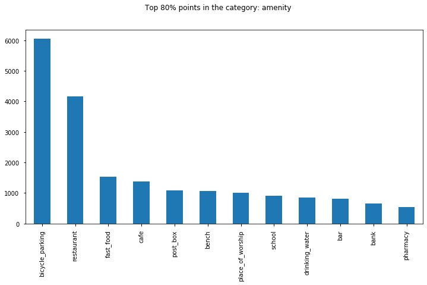

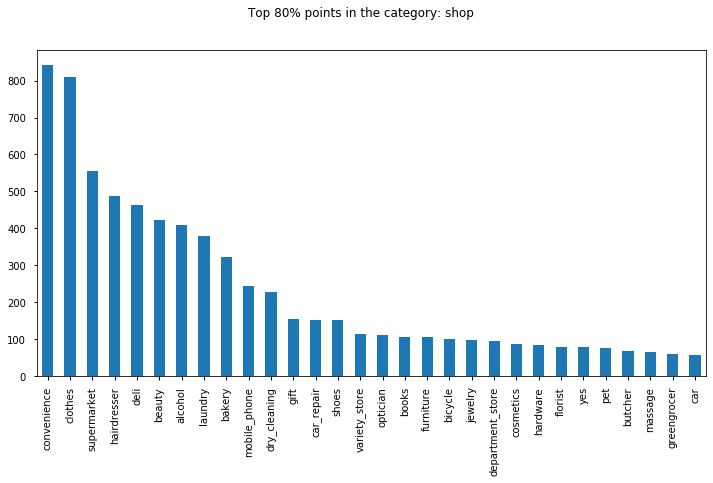

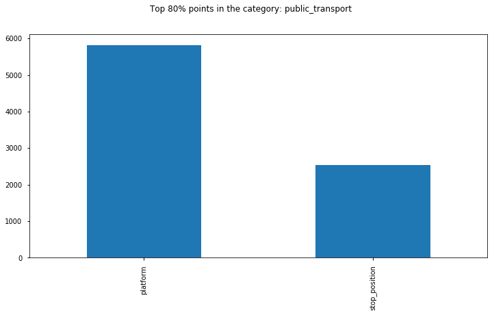

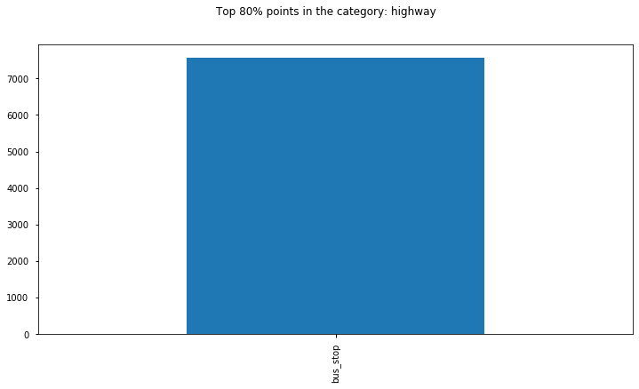

```python
def get_top_perc(series, perc_value=.8):
    perc = series.cumsum() / series.sum()
    arg = (perc > perc_value).values.argmax()
    return series.iloc[:arg+1]

for col in get_categories():
    p = .8
    valc = pois_df[col].value_counts()
    valf = get_top_perc(valc, p)
    fig, ax = plt.subplots()
    valf.plot(kind='bar', ax=ax)
    ax.set_xticklabels(ax.get_xticklabels(), rotation=90)
    fig.suptitle(f"Top {p*100:.0f}% points in the category: {col}")
```

From the charts we know that amenity and shop categories have many types (but with quite different occurrences), while public transport and highway contain only a few.

### Exercise 1.4

It is time to draw our POIs on a real map. We can define a Map class for the task.

#### Colormaps

We will make use of matplolib's colormaps. Let's talk about them briefly. By streamlining, every colormap can be seen as a continuous sequence of colors, interpolating between an initial and a final one. The choice of the two edge colors changes the nature of the scale (e.g. sequential, divergent). You can can get a colormap object with the `get_cmap`. Let's try with *viridis* and *BrBG* , a Perceptually Uniform Sequential map and a Divergent map respectively.

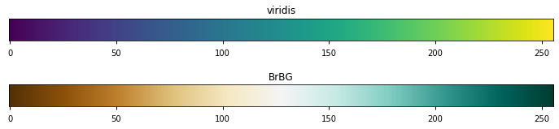

```python
from matplotlib.cm import get_cmap

x = np.linspace(0, 1, 256)
x = np.vstack((x, x))
fig, axes = plt.subplots(nrows=2, figsize=(12,2))
plt.subplots_adjust(hspace=2) # adjust the vertical space between subplots

for ax, name in zip(axes, ['viridis', 'BrBG']):
    ax.imshow(x, aspect='auto', cmap=plt.get_cmap(name))
    ax.grid(False)
    ax.get_yaxis().set_visible(False)
    ax.set_title(name)
```

As you might have noticed, the values of `x` (i.e. 256 floating point numbers linearly distributed between 0 and 1) are used to pick colors from the colormap.

```python
x[0, :10]
```

```
array([0.        , 0.00392157, 0.00784314, 0.01176471, 0.01568627,
       0.01960784, 0.02352941, 0.02745098, 0.03137255, 0.03529412])
```

Each color is expressed as four floating point numbers (RGBA notation) between 0 and 1. To get these values, use the callable nature of the colormap object itself.

```python
cmap = plt.get_cmap('viridis')
cmap(x[0, :10])
```

```
array([[0.267004, 0.004874, 0.329415, 1.      ],
       [0.26851 , 0.009605, 0.335427, 1.      ],
       [0.269944, 0.014625, 0.341379, 1.      ],
       [0.271305, 0.019942, 0.347269, 1.      ],
       [0.272594, 0.025563, 0.353093, 1.      ],
       [0.273809, 0.031497, 0.358853, 1.      ],
       [0.274952, 0.037752, 0.364543, 1.      ],
       [0.276022, 0.044167, 0.370164, 1.      ],
       [0.277018, 0.050344, 0.375715, 1.      ],
       [0.277941, 0.056324, 0.381191, 1.      ]])
```

#### Map class

```python
import seaborn as sns

class Map:
    def __init__(self, df):
        """ Store Dataset with POIs information."""
        self.pois_df = df
        self.lat_min = df['@lat'].min()
        self.lat_max = df['@lat'].max()
        self.long_min = df['@lon'].min()
        self.long_max = df['@lon'].max()

    def plot_map(self):
        """ Display an image with NY map and return the Axes object."""
        fig, ax = plt.subplots()
        nyc_img = plt.imread('./New_York_City_Map.PNG')
        ax.imshow(nyc_img, zorder=0, extent=[self.long_min,
                                             self.long_max,
                                             self.lat_min,
                                             self.lat_max])
        ax.grid(False)
        return ax

    def plot_pois(self, ax, category, mask):
        """Plot data on specified Axis."""
        df = self.pois_df.loc[mask]

        # Version 1: using pandas
        types = df[category].unique()
        cmap = get_cmap('viridis')
        colors = cmap(np.linspace(0, 1, types.size))
        for i, t in enumerate(types):
            df_t = df.loc[df[category] == t]
            c = [colors[i]] *  df_t.shape[0]
            df_t.plot.scatter(x='@lon', y='@lat', ax=ax, c=c, alpha=.6, label=t)

        # Version 2: using seaborn
        # sns.scatterplot(df['@lon'], df['@lat'], hue=df[category], ax=ax,
        #                 marker='o', s=3, linewidth=0, palette="viridis", legend='full')

        ax.legend() # show the legend, required by Version 1
        ax.grid(False)
        return ax
```

The class exposes a method that creates a new figure, draws the New York map onto it, and finally returns the Axes object for future plots. Focus on the `extent` parameter: it is used to specify the top, bottom, left and right margins of the image, in terms of coordinates. In this case, it is required to correctly align the background with our latitude and longitude values. Without prior knowledge on that, we can suppose that the image provided with the dataset is bounded to the area that ranges from minimum and maximum values of both latitude and longitude, considering all POIs. We can check if the latter assumption was correct by simply plotting a category POIs.

We would like you to focus on the `plot_pois` method. The actual plotting is presented in two versions: one with pandas functions and one with the seaborn library. The uncommented version exploits pandas. As you can see, the approach requires to:

- get the series of distinct types (here we have already filtered the most frequent ones);
- get a matplolib colormap and sample a number of colors out of it equal to the number of different types;
- for each type, plot POIs relative to it specifying the color and the label

The commented line (i.e. Version 2) uses the seaborn library to obtain the same result. The `hue` parameter is used to infer the labels and the color of each data point, while `palette` lets you select the desired colormap. Pretty neat, isn't it?

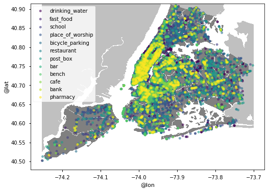

```python
def show_category_on_map(df, column, perc_value):
    """
    Plot the New York map with POIs of a specific category.
    Only the top 'perc_value'% frequent types are plotted.
    """
    counts = df[column].value_counts()
    top_freq = get_top_perc(counts, perc_value)
    ny_map = Map(df)

    ax = ny_map.plot_map()
    mask = df[column].isin(top_freq.index)
    ny_map.plot_pois(ax, column, mask)

show_category_on_map(pois_df, 'amenity', .8)
```

There is an evident concentration of pharmacies in the Manhattan neighborhood. However, we should consider that latest calls may superimpose points on top of the ones drawn by first calls. Let's look at the same chart, lowering the frequency threshold.

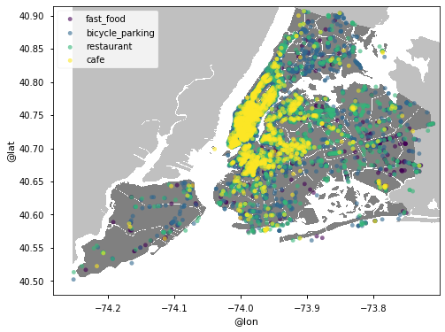

```python
show_category_on_map(pois_df, 'amenity', .5)
```

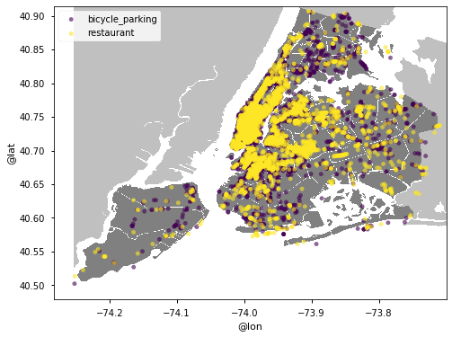

```python
show_category_on_map(pois_df, 'amenity', .3)
```

Manhattan seems to be the core of many of the most frequent types of amenities.

### Exercise 1.5

We focus now on a grid-based subdivision system. The rationale here follows the rule of data transformation: we want to explore POIs from another perspective, starting from another representation. Lets see how it can be achieved.

We can decide to subdivide the map into non-overlapping, rectangular-shaped cells based on latitude and longitude. Even this is not the only possibility, a grid like that guarantees that each point will fall into a single cell.

Let's write down a class to map POIs' coordinates to the respective cell (or cell_id).

```python
class Cell_converter:
    def __init__(self, df, n_splits):
        self.lat_min = df['@lat'].min()
        self.lat_max = df['@lat'].max()
        self.long_min = df['@lon'].min()
        self.long_max = df['@lon'].max()
        self.n_splits = n_splits

    def plot_grid(self, ax):
        lat_steps = np.linspace(self.lat_min, self.lat_max, self.n_splits + 1)
        long_steps = np.linspace(self.long_min, self.long_max, self.n_splits + 1)
        ax.hlines(lat_steps, self.long_min, self.long_max)
        ax.vlines(long_steps, self.lat_min, self.lat_max)

    def point_to_cell_coord(self, long, lat):
        x = int((long - self.long_min)/(self.long_max - self.long_min)*self.n_splits)
        y = int((lat - self.lat_min)/(self.lat_max - self.lat_min)*self.n_splits)
        return x, y

    def point_to_cell_id(self, long, lat):
        x, y = self.point_to_cell_coord(long, lat)
        return y * n_splits + x

n_splits = 20
cell_conv = Cell_converter(pois_df, n_splits)

pois_df['cell_id'] = pois_df.apply(lambda x: cell_conv.point_to_cell_id(x['@lon'], x['@lat']), axis=1)
pois_df.head()
```

| @id | @type | @lat | @lon | amenity | name | shop | public_transport | highway | cell_id |
| --- | --- | --- | --- | --- | --- | --- | --- | --- | --- |
| 42432939 | node | 40.814104 | -73.949623 | NaN | NaN | NaN | stop_position | NaN | 310 |
| 42448838 | node | 40.761647 | -73.949864 | NaN | NaN | NaN | stop_position | NaN | 250 |
| 42723103 | node | 40.852182 | -73.772677 | ferry_terminal | Hart Island Ferry Terminal | NaN | NaN | NaN | 337 |
| 42764076 | node | 40.867164 | -73.882158 | NaN | Botanical Garden | NaN | stop_position | NaN | 353 |
| 42811266 | node | 40.704807 | -73.772734 | NaN | NaN | NaN | stop_position | NaN | 197 |

The `point_to_cell_id` method creates the final mapping. As you can see, the `cell_id` will be an integer, starting from 0 (the bottom-left cell) and following a row major ordering.

Also, focus on line 27. That is a simply way to assign the result of some operation to a new column, by effectively creating it at the moment.

#### Bonus

As you might have understood, we do like maps, scatter plots, and scatter plots on maps. But we do not dislike grids too. That is the reason for the presence of the `plot_grid` method. Let's apply it.

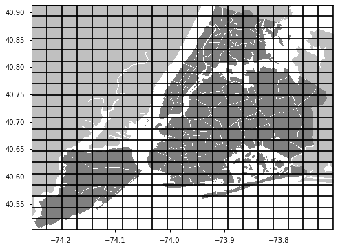

```python
yet_another_map = Map(pois_df)
ax = yet_another_map.plot_map()
cell_conv.plot_grid(ax)
```

### Exercise 1.6

Now that we have the `cell_id` assigned, we are able to carry out a different analysis.  
The *cell-wise* distribution of POIs re-frames the exploration task, providing a completely new representation of our dataset. The obtained cells (that now represent a specific sub-area in the NY municipality) become atomic units, summarizing part of our data.

As such, we can decide to characterize each cell by counting the POIs contained, for each POI type. The outcome will be a new DataFrame.

```python
def get_df_count(df, column, perc_value):
    counts = df[column].value_counts()
    top_freq = get_top_perc(counts, perc_value)
    mask = df[column].isin(top_freq.index)
    freq_df = df.loc[mask]

    # for each cell_id count the number of POIs for each type
    count_dframe = []
    for cell_id in range(n_splits**2):
        count_vals = freq_df.loc[freq_df['cell_id'] == cell_id][column].value_counts()
        count_vals.name = cell_id
        count_dframe.append(count_vals)

    cells_features_df = pd.DataFrame(count_dframe)
    cells_features_df = cells_features_df.fillna(0)
    return cells_features_df
```

Let's see a few records of the result for frequent amenities.

```python
amenities_df = get_df_count(pois_df, 'amenity', .6)
amenities_df.head()
```

|  | restaurant | post_box | bicycle_parking | fast_food | cafe | bench |
| --- | --- | --- | --- | --- | --- | --- |
| 0 | 2.0 | 2.0 | 1.0 | 1.0 | 0.0 | 0.0 |
| 1 | 0.0 | 0.0 | 0.0 | 0.0 | 1.0 | 0.0 |
| 2 | 0.0 | 0.0 | 0.0 | 0.0 | 0.0 | 0.0 |
| 3 | 0.0 | 0.0 | 0.0 | 0.0 | 0.0 | 0.0 |
| 4 | 0.0 | 0.0 | 0.0 | 0.0 | 0.0 | 0.0 |

### Exercise 1.7

Now that we have some new features to characterize each cell, we can inspect whether they are correlated or not. This kind of question becomes interesting especially with data from different categories.

Let's begin computing the cell-wise representation for shops as well.

```python
shops_df = get_df_count(pois_df, 'shop', .6)
shops_df.head()
```

|  | supermarket | convenience | gift | clothes | alcohol | bakery | beauty | laundry | hairdresser | deli | mobile_phone | dry_cleaning |
| --- | --- | --- | --- | --- | --- | --- | --- | --- | --- | --- | --- | --- |
| 0 | 1.0 | 0.0 | 0.0 | 0.0 | 0.0 | 0.0 | 0.0 | 0.0 | 0.0 | 0.0 | 0.0 | 0.0 |
| 1 | 0.0 | 0.0 | 0.0 | 0.0 | 0.0 | 0.0 | 0.0 | 0.0 | 0.0 | 0.0 | 0.0 | 0.0 |
| 2 | 0.0 | 0.0 | 0.0 | 0.0 | 0.0 | 0.0 | 0.0 | 0.0 | 0.0 | 0.0 | 0.0 | 0.0 |
| 3 | 0.0 | 0.0 | 0.0 | 0.0 | 0.0 | 0.0 | 0.0 | 0.0 | 0.0 | 0.0 | 0.0 | 0.0 |
| 4 | 0.0 | 0.0 | 0.0 | 0.0 | 0.0 | 0.0 | 0.0 | 0.0 | 0.0 | 0.0 | 0.0 | 0.0 |

Now, concatenate it with the DataFrame from amenities. Remember that the *horizontal stacking* operation (i.e. on columns) is obtained with `axis=1`.

```python
final_df = pd.concat([amenities_df, shops_df], axis=1)
```

Pandas provides an handy method to compute the pairwise correlation of columns, excluding null values. We can adopt the resulting matrix to build an heatmap.

```python
final_corr = final_df.corr()
final_corr.head()
```

|  | restaurant | post_box | bicycle_parking | fast_food | cafe | bench | supermarket | convenience | gift | clothes | alcohol | bakery | beauty | laundry | hairdresser | deli | mobile_phone | dry_cleaning |
| --- | --- | --- | --- | --- | --- | --- | --- | --- | --- | --- | --- | --- | --- | --- | --- | --- | --- | --- |
| restaurant | 1.000000 | 0.738146 | 0.933327 | 0.892643 | 0.977129 | 0.325605 | 0.854280 | 0.698709 | 0.748171 | 0.897885 | 0.893299 | 0.934591 | 0.641513 | 0.533456 | 0.702188 | 0.527927 | 0.697886 | 0.779390 |
| post_box | 0.738146 | 1.000000 | 0.757908 | 0.791383 | 0.751239 | 0.464872 | 0.831700 | 0.732534 | 0.572624 | 0.640424 | 0.854463 | 0.730414 | 0.744983 | 0.700626 | 0.764960 | 0.669046 | 0.747977 | 0.802623 |
| bicycle_parking | 0.933327 | 0.757908 | 1.000000 | 0.823712 | 0.922268 | 0.381228 | 0.858209 | 0.633704 | 0.662442 | 0.839809 | 0.873462 | 0.888446 | 0.673453 | 0.522363 | 0.745809 | 0.490781 | 0.607225 | 0.793769 |
| fast_food | 0.892643 | 0.791383 | 0.823712 | 1.000000 | 0.931877 | 0.463410 | 0.762383 | 0.707077 | 0.808271 | 0.790148 | 0.856165 | 0.759500 | 0.726217 | 0.557794 | 0.758824 | 0.574192 | 0.776886 | 0.822514 |
| cafe | 0.977129 | 0.751239 | 0.922268 | 0.931877 | 1.000000 | 0.407526 | 0.813572 | 0.694446 | 0.786491 | 0.875035 | 0.901696 | 0.874180 | 0.657689 | 0.508593 | 0.732542 | 0.480233 | 0.690048 | 0.813883 |

Again, let's develop two versions, to highlight how the seaborn library can significantly simplify your tasks. As you can see, matplotlib does not provide a method *out-of-the-shelf*. You should rely instead on the image show functionality, adjusting axes and adding a colorbar by yourself. Conversely, the seaborn implementation (the commented one), for the same result, would require a single line of code.

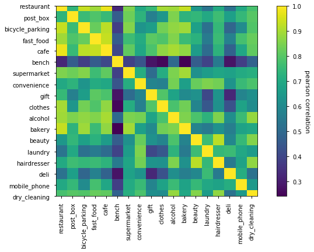

```python
# Version 1
fig, ax = plt.subplots()
im = ax.imshow(final_corr)
ax.set_xticks(np.arange(final_corr.columns.size))
ax.set_yticks(np.arange(final_corr.columns.size))
ax.set_xticklabels(final_corr.columns)
ax.set_yticklabels(final_corr)
plt.setp(ax.get_xticklabels(), rotation=90, ha="right", va="center",
         rotation_mode="anchor") # rotate labels on x-axis
cbar = ax.figure.colorbar(im, ax=ax)
_ = cbar.ax.set_ylabel('pearson correlation', rotation=-90, va="bottom")

# Version 2
# sns.heatmap(final_corr)
```

There are some interesting couples, like restaurant with bicycle parking, fast food, cafe, clothes and bakery. These NY areas are likely related to food activities. Laundry is highly correlated with convenience shops, beauty, hairdresser and dry cleaning. The latter seems to identify cells with commercial activities and shops.

Bear in mind that these are preliminary results. Cells nature may vary, depending on the parameter `n_steps` used to build the grid. Also, remeber that we focused on amenities and shops only and, among them, we filtered out the 40% less frequent POI types. Further analyzes are left to you, as side exercise.

#### Bonus

The main idea behind correlation inspection is to find cells where some activities or shops appear together. We can take the analysis one step further and search for clusters of cells. Given the new representation at our disposal (i.e. cells characterized by the presence of certain POIs), computing clusters of cells would be equivalent to discovering areas of interest in the city.

We left cluster analysis to you, as side exercise. Among all possible research questions, you could focus on:

- which are the POIs that distinguish the obtained clusters the most?
- can you spot areas of interest looking at POIs distribution in each cluster?
- are the cells belonging to the same cluster close also geographically?

## Exercise 2: Data exploration and queries on Flight Delay Data

### Exercise 2.1

We begin by loading the dataset. The argument `parse_dates` is used to parse a raw date string to a numpy datetime64 object. Pandas time series / date [functionalities](https://pandas.pydata.org/pandas-docs/stable/user_guide/timeseries.html) are extremely versatile and should be used anytime a column represents a date or timestamp. Working with datetime types lets you, for example, query specific dates (without using string comparison) or date intevals. That becomes extremely useful when the DataFrame index is of type datetime. The actual class is known as [DatetimeIndex](https://pandas.pydata.org/pandas-docs/stable/reference/api/pandas.DatetimeIndex.html).

```python
df = pd.read_csv('data/831394006_T_ONTIME.csv', parse_dates=["FL_DATE"]).rename(columns=str.lower)
```

### Exercise 2.2

Let's call now some descriptive methods.

```python
df.head()
```

|  | fl_date | unique_carrier | airline_id | tail_num | fl_num | origin_airport_id | origin_airport_seq_id | origin_city_market_id | origin | origin_city_name | ... | arr_time | arr_delay | cancelled | cancellation_code | carrier_delay | weather_delay | nas_delay | security_delay | late_aircraft_delay | unnamed: 32 |
| --- | --- | --- | --- | --- | --- | --- | --- | --- | --- | --- | --- | --- | --- | --- | --- | --- | --- | --- | --- | --- | --- |
| 0 | 2017-01-01 | AA | 19805 | N787AA | 1 | 12478 | 1247803 | 31703 | JFK | New York, NY | ... | 1209.0 | 27.0 | 0.0 | NaN | 27.0 | 0.0 | 0.0 | 0.0 | 0.0 | NaN |
| 1 | 2017-01-01 | AA | 19805 | N783AA | 2 | 12892 | 1289204 | 32575 | LAX | Los Angeles, CA | ... | 1809.0 | 42.0 | 0.0 | NaN | 34.0 | 0.0 | 8.0 | 0.0 | 0.0 | NaN |
| 2 | 2017-01-01 | AA | 19805 | N791AA | 4 | 12892 | 1289204 | 32575 | LAX | Los Angeles, CA | ... | 2040.0 | 42.0 | 0.0 | NaN | 7.0 | 0.0 | 0.0 | 0.0 | 35.0 | NaN |
| 3 | 2017-01-01 | AA | 19805 | N391AA | 5 | 11298 | 1129804 | 30194 | DFW | Dallas/Fort Worth, TX | ... | 1749.0 | 97.0 | 0.0 | NaN | 77.0 | 0.0 | 20.0 | 0.0 | 0.0 | NaN |
| 4 | 2017-01-01 | AA | 19805 | N346AA | 6 | 13830 | 1383002 | 33830 | OGG | Kahului, HI | ... | 642.0 | 42.0 | 0.0 | NaN | 0.0 | 0.0 | 42.0 | 0.0 | 0.0 | NaN |

5 rows × 33 columns

```python
df.describe()
```

|  | airline_id | fl_num | origin_airport_id | origin_airport_seq_id | origin_city_market_id | dest_airport_id | dest_airport_seq_id | dest_city_market_id | crs_dep_time | dep_time | ... | crs_arr_time | arr_time | arr_delay | cancelled | carrier_delay | weather_delay | nas_delay | security_delay | late_aircraft_delay | unnamed: 32 |
| --- | --- | --- | --- | --- | --- | --- | --- | --- | --- | --- | --- | --- | --- | --- | --- | --- | --- | --- | --- | --- | --- |
| count | 450017.000000 | 450017.000000 | 450017.000000 | 4.500170e+05 | 450017.000000 | 450017.000000 | 4.500170e+05 | 450017.000000 | 450017.000000 | 441476.000000 | ... | 450017.000000 | 440746.000000 | 439645.000000 | 450017.000000 | 97699.000000 | 97699.000000 | 97699.000000 | 97699.000000 | 97699.000000 | 0.0 |
| mean | 19900.483275 | 2079.643193 | 12698.267568 | 1.269830e+06 | 31738.603264 | 12698.024626 | 1.269805e+06 | 31738.404640 | 1327.757407 | 1333.947392 | ... | 1506.278285 | 1487.332958 | 6.954484 | 0.019746 | 20.308836 | 3.368857 | 15.742495 | 0.079745 | 24.947492 | NaN |
| std | 385.381448 | 1722.700045 | 1534.326936 | 1.534324e+05 | 1286.063689 | 1534.246611 | 1.534244e+05 | 1285.791081 | 481.548320 | 494.957196 | ... | 501.853851 | 523.821795 | 49.595992 | 0.139126 | 60.649157 | 27.809756 | 32.328181 | 2.896287 | 47.850860 | NaN |
| min | 19393.000000 | 1.000000 | 10135.000000 | 1.013503e+06 | 30070.000000 | 10135.000000 | 1.013503e+06 | 30070.000000 | 5.000000 | 1.000000 | ... | 1.000000 | 1.000000 | -98.000000 | 0.000000 | 0.000000 | 0.000000 | 0.000000 | 0.000000 | 0.000000 | NaN |
| 25% | 19690.000000 | 679.000000 | 11292.000000 | 1.129202e+06 | 30647.000000 | 11292.000000 | 1.129202e+06 | 30647.000000 | 917.000000 | 921.000000 | ... | 1120.000000 | 1108.000000 | -15.000000 | 0.000000 | 0.000000 | 0.000000 | 0.000000 | 0.000000 | 0.000000 | NaN |
| 50% | 19805.000000 | 1602.000000 | 12892.000000 | 1.289204e+06 | 31454.000000 | 12892.000000 | 1.289204e+06 | 31454.000000 | 1321.000000 | 1330.000000 | ... | 1529.000000 | 1521.000000 | -5.000000 | 0.000000 | 0.000000 | 0.000000 | 4.000000 | 0.000000 | 3.000000 | NaN |
| 75% | 20304.000000 | 3034.000000 | 14057.000000 | 1.405702e+06 | 32467.000000 | 14057.000000 | 1.405702e+06 | 32467.000000 | 1730.000000 | 1738.000000 | ... | 1921.000000 | 1921.000000 | 11.000000 | 0.000000 | 17.000000 | 0.000000 | 20.000000 | 0.000000 | 31.000000 | NaN |
| max | 21171.000000 | 7439.000000 | 16218.000000 | 1.621801e+06 | 35991.000000 | 16218.000000 | 1.621801e+06 | 35991.000000 | 2359.000000 | 2400.000000 | ... | 2359.000000 | 2400.000000 | 1944.000000 | 1.000000 | 1934.000000 | 1934.000000 | 1457.000000 | 653.000000 | 1392.000000 | NaN |

8 rows × 25 columns

```python
df.info()
```

```
<class 'pandas.core.frame.DataFrame'>
RangeIndex: 450017 entries, 0 to 450016
Data columns (total 33 columns):
fl_date                  450017 non-null datetime64[ns]
unique_carrier           450017 non-null object
airline_id               450017 non-null int64
tail_num                 449378 non-null object
fl_num                   450017 non-null int64
origin_airport_id        450017 non-null int64
origin_airport_seq_id    450017 non-null int64
origin_city_market_id    450017 non-null int64
origin                   450017 non-null object
origin_city_name         450017 non-null object
dest_airport_id          450017 non-null int64
dest_airport_seq_id      450017 non-null int64
dest_city_market_id      450017 non-null int64
dest                     450017 non-null object
dest_city_name           450017 non-null object
crs_dep_time             450017 non-null int64
dep_time                 441476 non-null float64
dep_delay                441476 non-null float64
taxi_out                 441244 non-null float64
wheels_off               441244 non-null float64
wheels_on                440746 non-null float64
taxi_in                  440746 non-null float64
crs_arr_time             450017 non-null int64
arr_time                 440746 non-null float64
arr_delay                439645 non-null float64
cancelled                450017 non-null float64
cancellation_code        8886 non-null object
carrier_delay            97699 non-null float64
weather_delay            97699 non-null float64
nas_delay                97699 non-null float64
security_delay           97699 non-null float64
late_aircraft_delay      97699 non-null float64
unnamed: 32              0 non-null float64
dtypes: datetime64[ns](1), float64(15), int64(10), object(7)
memory usage: 113.3+ MB
```

The dataset is sufficently large (450k entries, 33 columns and 113 MB of memory footprint). We can easily note that the attribute *unnamed: 32* is null everywhere. Even if it is not strictly necessary, let's get rid of it.

```python
df = df.drop("unnamed: 32", axis=1)
```

Let's list all available carries airports and count them.

```python
df.unique_carrier.unique(), df.unique_carrier.unique().size
```

```
(array(['AA', 'B6', 'EV', 'HA', 'NK', 'OO', 'UA', 'VX', 'AS', 'WN', 'DL',
        'F9'], dtype=object), 12)
```

```python
distinct_airports = pd.concat([df["origin"], df["dest"]])
print(f"First ten airports: {distinct_airports.unique()[:10]}. Size: {distinct_airports.unique().size}")
```

```
First ten airports: ['JFK' 'LAX' 'DFW' 'OGG' 'HNL' 'SFO' 'ORD' 'MIA' 'IAH' 'BOS']. Size: 298
```

Note how we have accessed the DataFrame columns. The first one uses an object's attribute: pandas creates these attributes, matching the column names, at instantiation time. In the latter cell we used the square brackets. That syntax is more verbose but lets you specify a list of columns to slice on, returning a DataFrame as result.

```python
df[["origin", "dest"]]
```

|  | origin | dest |
| --- | --- | --- |
| 0 | JFK | LAX |
| 1 | LAX | JFK |
| 2 | LAX | JFK |
| 3 | DFW | HNL |
| 4 | OGG | DFW |
| ... | ... | ... |
| 450012 | FLL | MSP |
| 450013 | MSP | FLL |
| 450014 | ATL | PHL |
| 450015 | FLL | ATL |
| 450016 | FLL | LGA |

450017 rows × 2 columns

Since the `fl_date` is now a datetime64 column, we can ask for something like:

```python
df.fl_date.min(), df.fl_date.max()
```

```
(Timestamp('2017-01-01 00:00:00'), Timestamp('2017-01-31 00:00:00'))
```

### Exercise 2.3

We can filter out canceled flights for the following analysis.

```python
print('Shape before:', df.shape)
df = df.loc[df.cancelled == 0]
print('Shape after:', df.shape)
```

```
Shape before: (450017, 32)
Shape after: (441131, 32)
```

### Exercise 2.4

Using the groupby method we can obtain the two information.

```python
df_by_carrier = df.groupby('unique_carrier')
df_count = df_by_carrier['fl_date'].count()
df_count
```

```
unique_carrier
AA     72152
AS     14454
B6     24077
DL     69031
EV     33878
       ...
NK     12129
OO     48266
UA     42171
VX      5645
WN    105472
Name: fl_date, Length: 12, dtype: int64
```

```python
df_by_carrier[['carrier_delay',
               'weather_delay',
               'nas_delay',
               'security_delay',
               'late_aircraft_delay']].mean()
```

| unique_carrier | carrier_delay | weather_delay | nas_delay | security_delay | late_aircraft_delay |
| --- | --- | --- | --- | --- | --- |
| AA | 18.736410 | 2.352168 | 15.370026 | 0.178156 | 18.742267 |
| AS | 11.736505 | 3.820850 | 18.615047 | 0.169028 | 19.189946 |
| B6 | 20.297641 | 1.436562 | 15.223725 | 0.312820 | 29.282627 |
| DL | 30.858959 | 9.572160 | 16.836252 | 0.033901 | 21.964020 |
| EV | 36.329407 | 1.368504 | 15.794439 | 0.000000 | 31.725109 |
| ... | ... | ... | ... | ... | ... |
| NK | 9.080825 | 0.732499 | 43.840041 | 0.035171 | 12.137978 |
| OO | 23.495640 | 4.633053 | 15.186582 | 0.100759 | 31.316244 |
| UA | 21.436417 | 2.568226 | 21.186162 | 0.016759 | 24.592458 |
| VX | 9.308965 | 3.342583 | 25.093917 | 0.041622 | 24.715582 |
| WN | 11.737663 | 2.176463 | 9.701419 | 0.031890 | 25.658966 |

12 rows × 5 columns

### Exercise 2.5

We have already seen how a new column can be generated. Since our `fl_date` is in datetime format, obtaining the day of the week is straightforward.

```python
df['weekday'] = df['fl_date'].dt.dayofweek
df['weekday'].head()
```

```
0    6
1    6
2    6
3    6
4    6
Name: weekday, dtype: int64
```

Then, a simple element-wise difference between columns is enough for `delaydelta`.

```python
df['deltadelay'] = df['arr_delay'] - df['dep_delay']
df['deltadelay'].head()
```

```
0    -4.0
1     8.0
2    -9.0
3    20.0
4    42.0
Name: deltadelay, dtype: float64
```

### Exercise 2.6

To accomplish the task we can use a boxplot. The boxplot is a method for graphically depicting numerical sets thorough their quartiles.

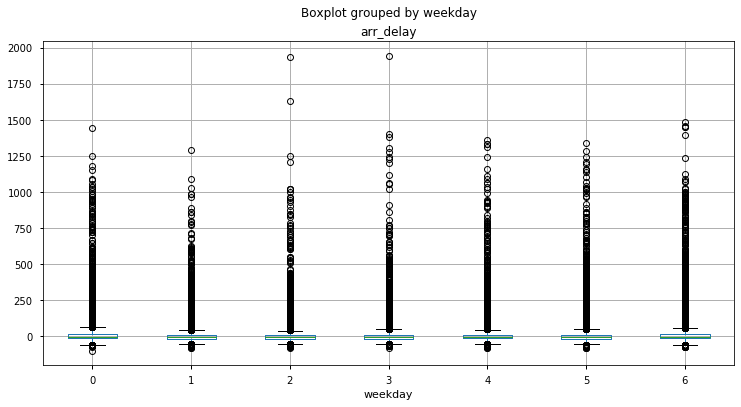

```python
df.boxplot(by='weekday', column='arr_delay')
```

Several outliers squeeze down each plot. Let's exclude them.

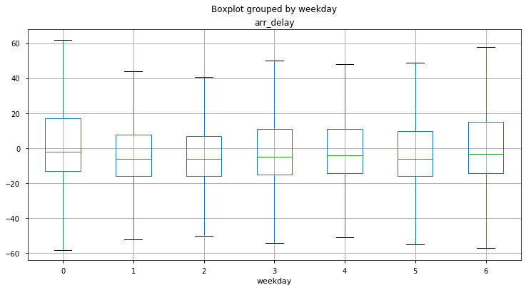

```python
df.boxplot(by='weekday', column='arr_delay', showfliers=False)
```

In both the cases, ther is no clear correlation between the arrival delay and the day of the week.

### Exercise 2.7

We can now exploit a bar chart.

```python
we_delay = df.loc[df.weekday > 4].groupby('unique_carrier').arr_delay.mean()
wd_delay = df.loc[df.weekday <= 4].groupby('unique_carrier').arr_delay.mean()

we_delay.name = "weekend delay"
wd_delay.name = "working days delay"
```

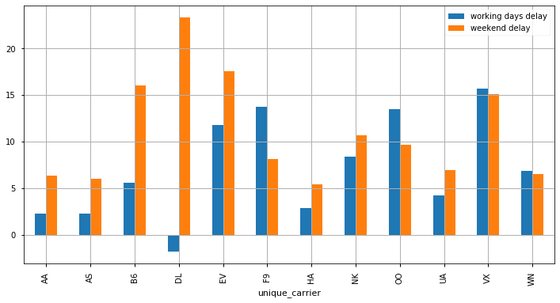

```python
ax = pd.concat([wd_delay, we_delay], axis=1).plot.bar()
ax.grid(True)
```

The most uneven behavior is obtained by Delta Airlines. Considering the working days, it has a negative mean delay, meaning that, on average, it landed its airplanes earlier than the scheduled time. Conversely, during weekends, it has the highest mean arrival delay.

### Exercise 2.8

The creation of the multi-index on an existing DataFrame is achieved by setting multiple columns to the index itself.

```python
multi_df = df.set_index(['unique_carrier', 'origin', 'dest', 'fl_date']).sort_index()
multi_df[multi_df.columns[:4]].head()
```

| unique_carrier | origin | dest | fl_date | airline_id | tail_num | fl_num | origin_airport_id |
| --- | --- | --- | --- | --- | --- | --- | --- |
| AA | ABQ | DFW | 2017-01-01 | 19805 | N4XSAA | 1282 | 10140 |
|  |  |  | 2017-01-01 | 19805 | N3NRAA | 2611 | 10140 |
|  |  |  | 2017-01-01 | 19805 | N4WNAA | 2402 | 10140 |
|  |  |  | 2017-01-02 | 19805 | N4XKAA | 2611 | 10140 |
|  |  |  | 2017-01-02 | 19805 | N4XBAA | 2402 | 10140 |

### Exercise 2.9

Working with multi-level indices is extremely useful sometimes. To access specific rows, you can specify an indexing procedure for each level.

```python
multi_df.loc[(['AA', 'DL'], ['LAX']), ['dep_time', 'dep_delay']]
```

| unique_carrier | origin | dest | fl_date | dep_time | dep_delay |
| --- | --- | --- | --- | --- | --- |
| AA | LAX | ATL | 2017-01-01 | 1051.0 | 16.0 |
|  |  |  | 2017-01-01 | 1747.0 | 137.0 |
|  |  |  | 2017-01-02 | 1548.0 | 18.0 |
|  |  |  | 2017-01-02 | 2230.0 | 40.0 |
|  |  |  | 2017-01-02 | 1055.0 | 20.0 |
| ... | ... | ... | ... | ... | ... |
| DL | LAX | TPA | 2017-01-26 | 1146.0 | 1.0 |
|  |  |  | 2017-01-27 | 1137.0 | -3.0 |
|  |  |  | 2017-01-29 | 1149.0 | 4.0 |
|  |  |  | 2017-01-30 | 1142.0 | -3.0 |
|  |  |  | 2017-01-31 | 1206.0 | 21.0 |

5437 rows × 2 columns

Note that the first element passed to `.loc` is a tuple, specifying a fancy indexing access on the first two levels of the index.

### Exercise 2.10

Let's break down the problem. We first detect all the interested records. To do so, we can exploit the datetime type to filter on dates.

```python
# fw_df = multi_df.loc[(:, :, 'LAX', '2017-01-01':'2017-01-08'), :] # not allowed
fw_df = multi_df.loc[(slice(None), slice(None), 'LAX', slice('2017-01-01','2017-01-08')), :]
```

The first line of the previous cell is commented out, since the character `:` cannot be used to access index levels. If you want to use it anyway, pandas provides the [IndexSlice object](https://pandas.pydata.org/pandas-docs/stable/user_guide/advanced.html) that handles the translation for you. The previous result would be obtained via:

```python
fw_df = multi_df.loc[pd.IndexSlice[:, :, 'LAX', '2017-01-01':'2017-01-08'], :]
```

We can now complete the task using again the groupby operator.

```python
fw_df.groupby('fl_num')['arr_delay'].mean()
```

```
fl_num
1        0.000000
2       60.000000
4       11.625000
5        2.875000
7       16.750000
          ...
6344    47.000000
6354    60.000000
6522    49.666667
6563    -8.000000
6710    10.000000
Name: arr_delay, Length: 1105, dtype: float64
```

### Exercise 2.11

It is time to explore the use of pandas pivot table. We want to count the flights departed each day of the week, for each carrier. Thus, the aggregation function would be `count`.

```python
cfd = pd.pivot_table(df, values='fl_num', index='unique_carrier', columns='weekday', aggfunc='count')
cfd
```

| weekday unique_carrier | 0 | 1 | 2 | 3 | 4 | 5 | 6 |
| --- | --- | --- | --- | --- | --- | --- | --- |
| AA | 12035 | 11457 | 9651 | 9854 | 9820 | 7905 | 11430 |
| AS | 2440 | 2261 | 1806 | 1935 | 1953 | 1762 | 2297 |
| B6 | 4063 | 3942 | 3143 | 3258 | 3169 | 2643 | 3859 |
| DL | 12157 | 11512 | 9248 | 9695 | 9521 | 6492 | 10406 |
| EV | 5935 | 5649 | 4627 | 4923 | 4774 | 2905 | 5065 |
| ... | ... | ... | ... | ... | ... | ... | ... |
| NK | 1954 | 1970 | 1616 | 1610 | 1563 | 1470 | 1946 |
| OO | 8321 | 7912 | 6413 | 6631 | 6667 | 4913 | 7409 |
| UA | 7498 | 6883 | 5384 | 5956 | 5920 | 3964 | 6566 |
| VX | 986 | 914 | 741 | 791 | 792 | 522 | 899 |
| WN | 17913 | 17855 | 14260 | 14220 | 14012 | 11168 | 16044 |

12 rows × 7 columns

Then, to compute the pairwise correlation between the carriers on different days we can count again on the pandas `corr()` method. However, it is applied to columns, hence we first need to transpose the DataFrame. The result is directly passed to seaborn for the heatmap visualization.

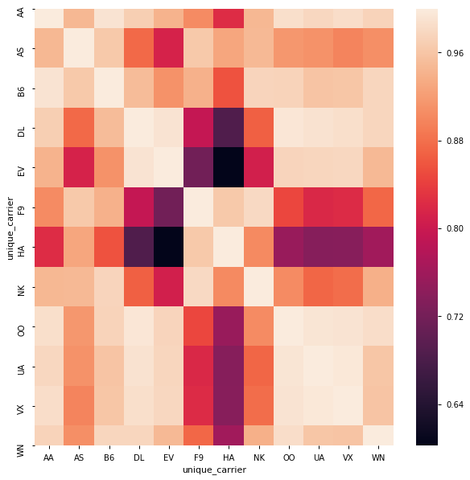

```python
plt.figure(figsize=(10,10))
_ = sns.heatmap(cfd.T.corr())
```

The matrix represents a degree of correlation along the week (the [Pearson correlation](https://en.wikipedia.org/wiki/Pearson_correlation_coefficient) is used by default): correlated carriers have operated the same number of flights in the same day of the week.

It seems that Hawaiian Airlines (HA) has a different flight schedule compared to most of the other companies. Conversely, Delta Airlines instead shares the plan with many companies.

### Exercise 2.12

Just as before, we need a pandas pivot table.

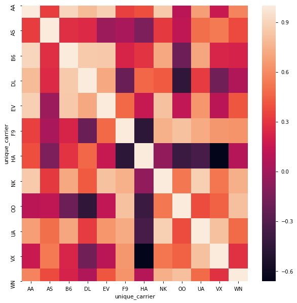

```python
plt.figure(figsize=(10,10))
_ = sns.heatmap(pd.pivot_table(df, values='arr_delay', index='unique_carrier', columns='weekday', aggfunc='mean').T.corr())
```

Now, an high correlation means that the two carriers have had the same mean arrival delay comparing the same days of the week. AA and DL, and VX and HA have an high correlation, positive and negative respectively. The rest of the heatmap does not bring significant information.

### Exercise 2.13

We need again a pivot table, but the input DataFrame needs to be filtered beforehand. To do so, we can make use of a boolean mask.

```python
mask = df.unique_carrier.isin(["HA", "DL", "AA", "AS"])
dcw = pd.pivot_table(df.loc[mask], values='deltadelay', index='unique_carrier', columns='weekday', aggfunc='mean')
dcw
```

| weekday unique_carrier | 0 | 1 | 2 | 3 | 4 | 5 | 6 |
| --- | --- | --- | --- | --- | --- | --- | --- |
| AA | -3.576209 | -4.621619 | -4.601184 | -4.091436 | -3.553686 | -4.558771 | -3.747053 |
| AS | -1.690789 | -1.625446 | -1.889198 | -2.130705 | -2.624551 | -3.453872 | 0.542632 |
| DL | -8.913563 | -10.211625 | -10.544913 | -10.604603 | -9.623199 | -5.979988 | -7.001644 |
| HA | 0.258359 | 0.307772 | 0.759189 | 0.390762 | 0.746528 | 1.330508 | 1.207066 |

Finally, we can use the pandas `plot` method. Calling it on the whole DataFrame, a line for each column is created, with the index values on the x-axis. Thus, we only need to transpose the DataFrame in advance.

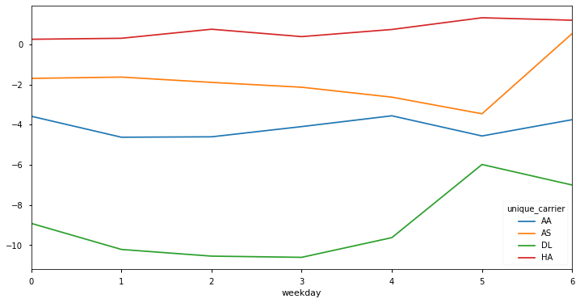

```python
dcw.T.plot()
```